# Filtrado y autocorrelación de puntos de presencia

4-15 de diciembre, 2023

# 1 Algunas ideas sobre la dependencia espacial.

- La primera ley de geografía; “todo está relacionado con todo lo demás, pero las cosas cercanas entre sí, están más relacionadas que las cosas distantes” (Tobler 1970).
- La dependencia espacial representa un problema para las inferencias estadísticas, porque los datos que contienen dependencia espacial no cumplen el supuesto estadístico común de independencia utilizado en muchas pruebas estadísticas (Legendre, 1993).
- La **autocorrelación espacial** es considerada como **dependencia espacial** que surge de **procesos endógenos** (e.g., dispersión localizada, o comportamiento social o de agrupación) (Fletcher y Fortin, 2018).

# 2 Filtrado espacial de puntos de presencia.

- Objetivo de la práctica: Contrastar el grado de **autocorrelación espacial** para diversos métodos de filtrado espacial y variables ambientales.

# 3 Flujo de trabajo:

3.1 Preparación de datos espaciales.

3.2 Selección aleatoria de registros.

3.3 Método de checkerboard1 del paquete [`ENMeval`](https://doi.org/10.1111/2041-210X.12261).

3.4 Filtrado espacial: 5, 20, y 50 km.

3.5 Filtrado ambiental del paquete [`flexsdm`](https://sjevelazco.github.io/flexsdm/).

3.6 Filtrado geográfico a partir del I de Moran.

## 3.1 Preparación de datos espaciales.

Primero cargamos los paquetes que utilizaremos.

```r
library(tidyverse)
library(terra)
library(sf)
library(flexsdm)
library(dplyr)
library(rgl)
library(ape)
library(ncf)
library(spdep)
library(ENMeval)
```

Establecemos el directorio de trabajo.

```r
# Establecemos el directorio de trabajo de la carpeta 'Auto_corr'.
setwd('E:/Auto_corr')
```

Cargamos los sets de registros de presencia que utilizaremos, los cuales corresponden a datos pre curados (Curación básica; sin duplicados, taxonomías correctas, precisión de coordenadas mínima de tres decimales, registros dentro del continente) [Cobos et. al. (2018)](https://doi.org/10.17161/bi.v13i0.7600). Cargamos los registros de presencia de la salamandra del altiplano “Ambystoma velasci”.

```r
spp <- read_csv('Ambystoma_velasci.csv')
# Exploramos el objeto spp
spp
```

```
## # A tibble: 728 × 8
##    sciname           name            longitude latitude prov  date  key   inside
##    <chr>             <chr>               <dbl>    <dbl> <chr> <chr> <chr> <lgl>
##  1 Ambystoma velasci Ambystoma vela…    -101.      23.2 SNIB  30/0… 7098… TRUE
##  2 Ambystoma velasci Ambystoma vela…     -99.3     19.9 SNIB  07/0… 7c84… TRUE
##  3 Ambystoma velasci Ambystoma vela…     -98.7     19.8 SNIB  <NA>  052b… TRUE
##  4 Ambystoma velasci Ambystoma vela…     -99.0     19.9 SNIB  20/0… 89ca… TRUE
##  5 Ambystoma velasci Ambystoma vela…     -98.1     20.1 SNIB  30/0… 98d0… TRUE
##  6 Ambystoma velasci Ambystoma vela…    -101.      22.1 SNIB  23/0… 8df8… TRUE
##  7 Ambystoma velasci Ambystoma vela…    -100.      21.9 SNIB  02/0… 8512… TRUE
##  8 Ambystoma velasci Ambystoma vela…     -97.4     19.4 SNIB  <NA>  01a7… TRUE
##  9 Ambystoma velasci Ambystoma vela…    -102.      21.5 SNIB  06/1… 082b… TRUE
## 10 Ambystoma velasci Ambystoma vela…     -98.7     20.2 SNIB  27/0… 4d1d… TRUE
## # ℹ 718 more rows
```

```r
# Nos quedamos con las columnas de interés.
spp <- spp %>% select(sciname, longitude, latitude)
```

Preparación de los datos de entrada.

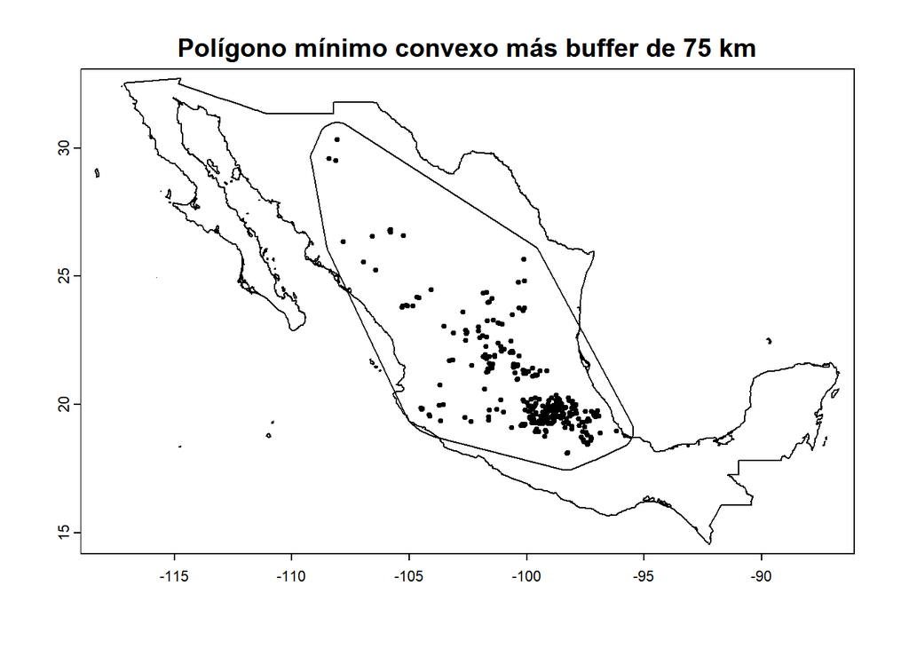

```r
# Cargamos un shp de México como referencia.
mex <- vect('Mexico/Mexico.shp')

#Definimos el área de calibración (M) como un polígono mínimo convexo ("bmcp") más un buffer de 75 km utilizando la función “calib_area()” del paquete `flexsdm`.
ca <- calib_area(
  data = spp,
  x = "longitude",
  y = "latitude",
  method = c("bmcp", width = 75000), # En metros usar ?calib_area para obtener información adicional.
  crs = crs(mex)
)

# Vemos como se ven nuestra M y los registros de presencia en la geografía.
plot(mex, main = "Polígono mínimo convexo más buffer de 75 km")
plot(ca, add = TRUE)
points(spp[, 2:3], pch = 19, cex = 0.5)
```

Utilizaremos dos variables ambientales; Bio 1 (Temperatura media anual) y EVI (Índice de Vegetación Aumentado el cual corresponde a la media mensual del periodo 2000-2023 del producto MOD13A3 Versión 6.1), ambas capas a ~1 km2 de resolución.

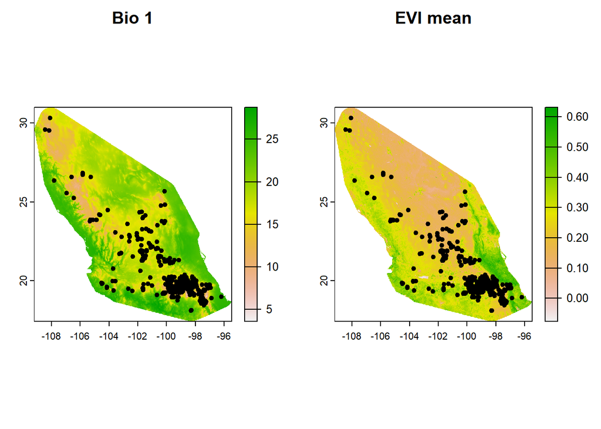

```r
bio1 <- rast("bio_1.tif")
evi.mean <- rast("EVI_mean.tif" )

# Realiza el recorte de EVI
evi.mean <- crop(evi.mean, ca)
evi.mean <- mask(evi.mean, ca)
evi.mean <- setNames(evi.mean, 'EVI_mean')

# Damos un vistazo.
par(mfrow = c(1, 2))
plot(bio1)
points(spp[,c('longitude','latitude')], pch = 20, bg =1)
title('Bio 1')
plot(evi.mean)
points(spp$longitude, spp$latitude, pch = 20, bg =1)
title('EVI mean')
```

Una vez preparada la data, comenzamos con los contrastes de filtrado espacial.

## 3.2 Selección aleatoria de registros.

Tomamos un subconjunto de los registros de presencia del 50%.

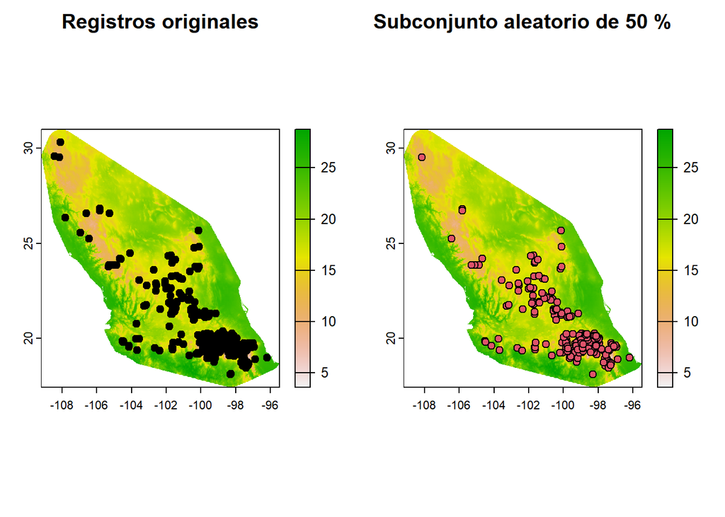

```r
set.seed(123)  # Para reproducibilidad, establece una semilla aleatoria.
spp.random <- spp[sample(nrow(spp), nrow(spp) * 0.5, replace = FALSE), ]

# ¿Cómo se ve?
par(mfrow = c(1, 2))
plot(bio1)
points(spp[,c('longitude','latitude')], pch = 21, bg =1)
title('Registros originales')
plot(bio1)
points(spp.random[,c('longitude','latitude')], pch = 21, bg =2)
title('Subconjunto aleatorio de 50 %')
```

Extraemos los valores de cada ráster.

```r
rand.bio <- terra::extract(bio1, spp.random[, c("longitude", "latitude")], df = TRUE) %>% tibble() %>% .[,-1] %>% tibble(spp.random[, c("longitude", "latitude")], .)
rand.evi <- terra::extract(evi.mean, spp.random[, c("longitude", "latitude")], df = TRUE) %>% tibble() %>% .[,-1] %>% tibble(spp.random[, c("longitude", "latitude")], .)
```

Utilizaremos la siguiente función que nos generará dos objetos `distmat y maxdist` que utilizaremos para generar correlogramas y hacer un test del I de Moran.

```r
 calc.dists <- function(x){
  #Calculamos una matriz de distancias a partir de las coordenadas de los registros de presencia.
  coords <- x %>% select(longitude, latitude)

  distmat <- as.matrix(dist(coords))

  #Calculamos la distancia máxima que utilizaremos para construir los correlogramas.
  maxdist <- 2/3 * max(distmat)

  # Devolver un objeto de lista con distmat y maxdist.
  result <- list(distmat = distmat, maxdist = maxdist )

  return(result)
}
```

Calculamos la matriz de distancia y la máxima distancia de nuestros registros con la función que cargamos anteriormente.

```r
rand.bio.dists <- calc.dists(rand.bio)
rand.evi.dists <- calc.dists(rand.evi)
```

Para generar los correlogramas para cada set de datos utilizaremos la función `spline.correlog()` del paquete `ncf` la cual genera correlogramas con intervalos de confianza mediante bootstrap.

```r
set.seed(123)
spline.rand.bio <- spline.correlog(x = rand.bio$longitude, y = rand.bio$latitude, z =rand.bio$bio_1, xmax = rand.bio.dists$maxdist, resamp = 100, type = "boot")
```

```
## 10  of  100
20  of  100
30  of  100
40  of  100
50  of  100
60  of  100
70  of  100
80  of  100
90  of  100
100  of  100
```

```r
set.seed(123)
spline.rand.evi <- spline.correlog(x = rand.evi$longitude, y = rand.evi$latitude, z =rand.evi$EVI_mean, xmax = rand.evi.dists$maxdist, resamp = 100, type = "boot")
```

```
## 10  of  100
20  of  100
30  of  100
40  of  100
50  of  100
60  of  100
70  of  100
80  of  100
90  of  100
100  of  100
```

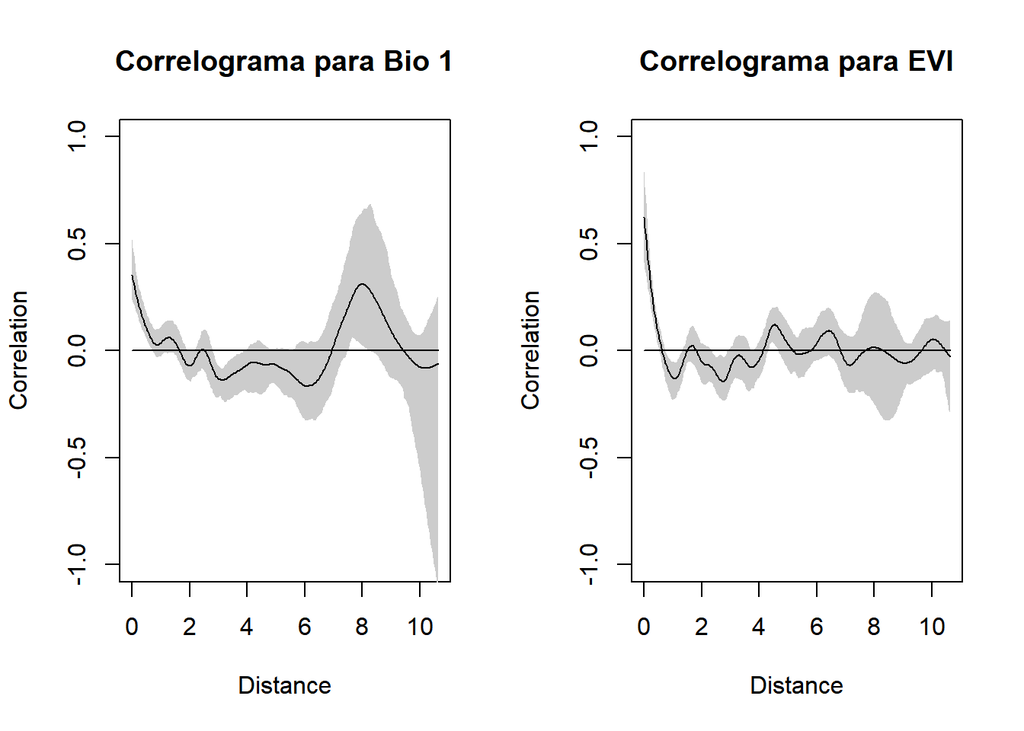

```r
# ¿Cómo se ve la autocorrelación?
par(mfrow = c(1, 2))
plot(spline.rand.bio)
title('Correlograma para Bio 1')
plot(spline.rand.evi)
title('Correlograma para EVI')
```

Ahora aremos una prueba de autocorrelación para obtener el I de Moran para cada set de datos. Pero primero establecemos los pasos necesarios dentro de una función que utiliza las funciones `dnearneigh` para identificar vecinos entre los registros, `nb2listw` que genera una lista de vecinos espaciales ponderada y `moran.mc` que calcula una prueba de permutación para el estadístico I de Moran, todas forman parte del paquete `spdep`. Los argumentos “d1” y “d2” corresponden a la distancia *mínima* y *máxima* a la que esperaríamos encontrar vecinos en los registros de la especie, respectivamente.

```r
m.test <- function(coords, envar, d2 = 3) {
  neigh <- dnearneigh(x = coords, d1 = 0, d2 = d2, longlat = TRUE)
  wts <- nb2listw(neighbours = neigh, style = 'W', zero.policy = TRUE)

  mor.mc <- moran.mc(x = envar, listw = wts,
                     nsim = 999, zero.policy = TRUE)
  print(mor.mc)
}
```

Aplicamos la prueba a cada conjunto de variables.

```r
m.test(rand.bio[,c("longitude", "latitude")], rand.bio$bio_1)
```

```
##
##  Monte-Carlo simulation of Moran I
##
## data:  envar
## weights: wts
## number of simulations + 1: 1000
##
## statistic = 0.51076, observed rank = 1000, p-value = 0.001
## alternative hypothesis: greater
```

```r
m.test(rand.evi[,c("longitude", "latitude")], rand.evi$EVI_mean)
```

```
##
##  Monte-Carlo simulation of Moran I
##
## data:  envar
## weights: wts
## number of simulations + 1: 1000
##
## statistic = 0.51145, observed rank = 1000, p-value = 0.001
## alternative hypothesis: greater
```

¿Qué tal, hay o no autocorrelación espacial?

El I de Moran es una estadística deductiva, bajo la *hipótesis nula de ausencia de autocorrelación espacial*, en estos casos obtuvimos un p < 0.005, lo que significa se rechaza la hipótesis nula. En términos más simples, el p-valor <0.05 sugiere evidencia suficiente para rechazar la idea de que no hay autocorrelación espacial en los datos, lo que implica que hay evidencia de autocorrelación espacial significativa.

## 3.3 Método de checkerboard1 del paquete [`ENMeval`](https://doi.org/10.1111/2041-210X.12261).

El método `checkerboard1` genera una partición de los registros de presencia en dos grupos (bins). El `aggregation.factor` especifica el número de celdas de cuadrícula a agregar al hacer el patrón de tablero de ajedrez subyacente.

Debido a que esta función requiere de un “background”, lo generamos de la siguiente manera:

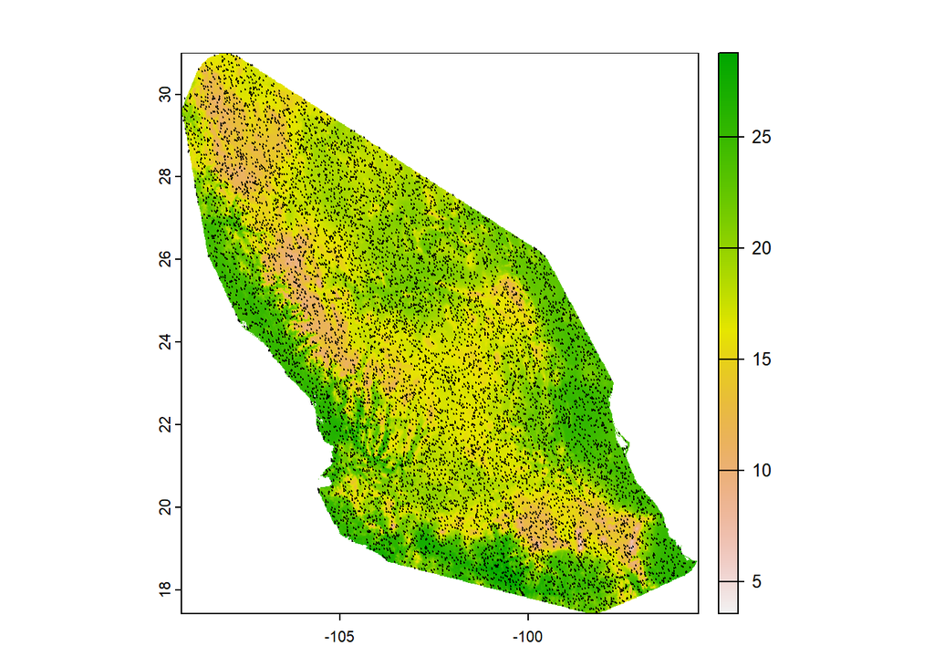

```r
# Generamos 10000 puntos aleatorios.
set.seed(123)
bg <- dismo::randomPoints(raster::raster(bio1), n = 10000)

plot(bio1)
points(bg, pch = 20, cex = 0.2)
```

Aplicamos la función a cada set de datos.

```r
set.seed(123)
chk1.bio <- get.checkerboard1(spp[, 2:3], bio1, bg, aggregation.factor = 10)
set.seed(123)
chk1.evi <- get.checkerboard1(spp[, 2:3], evi.mean, bg, aggregation.factor = 10)

# Exploramos la proporción de registros generada.
table(chk1.bio$occs.grp)
```

```
##
##   1   2
## 378 350
```

```r
table(chk1.evi$occs.grp)
```

```
##
##   1   2
## 377 351
```

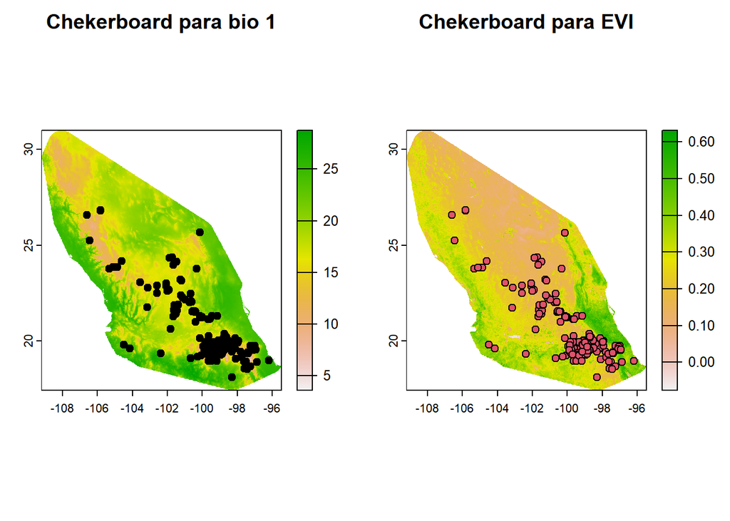

```r
# Nos quedamos con el primer conjunto de cada variable y generamos un data frame.
chk1.bio1.1 <- cbind(spp, type = chk1.bio$occs.grp) %>% tibble() %>% filter(type == 1)
chk1.evi.1 <- cbind(spp, type = chk1.evi$occs.grp) %>% tibble() %>% filter(type == 1)

# Le damos un vistazo a nuestros registros de presencia.
par(mfrow = c(1, 2))
plot(bio1)
points(chk1.bio1.1[,2:3], pch=21, bg=1)
title(main = "Chekerboard para bio 1")
plot(evi.mean)
points(chk1.evi.1[,2:3], pch=21, bg= 2)
title(main = "Chekerboard para EVI")
```

Extraemos los valores de cada variable ambiental.

```r
chk1.bio.env <- terra::extract(bio1, chk1.bio1.1[, c("longitude", "latitude")], df = TRUE) %>% tibble() %>% .[,-1] %>% tibble(chk1.bio1.1[, c("longitude", "latitude")], .)
chk1.evi.env <- terra::extract(evi.mean, chk1.evi.1[, c("longitude", "latitude")], df = TRUE) %>% tibble() %>% .[,-1] %>% tibble(chk1.evi.1[, c("longitude", "latitude")], .)
```

Calculamos las la matriz de distancias y la máxima distancia de los registros filtrados.

```r
chk1.bio.dists <- calc.dists(chk1.bio.env)
chk1.evi.dists <- calc.dists(chk1.evi.env)

# Calculamos los correlogramas suavizados con IC 95%.
set.seed(123)
spline.cor.bio.chk <- spline.correlog(x = chk1.bio.env$longitude, y = chk1.bio.env$latitude, z =chk1.bio.env$bio_1, xmax = chk1.bio.dists$maxdist, resamp = 100, type = "boot")
```

```
## 10  of  100
20  of  100
30  of  100
40  of  100
50  of  100
60  of  100
70  of  100
80  of  100
90  of  100
100  of  100
```

```r
set.seed(123)
spline.cor.evi.chk <- spline.correlog(x = chk1.evi.env$longitude, y = chk1.evi.env$latitude, z =chk1.evi.env$EVI_mean, xmax = chk1.evi.dists$maxdist, resamp = 100, type = "boot")
```

```
## 10  of  100
20  of  100
30  of  100
40  of  100
50  of  100
60  of  100
70  of  100
80  of  100
90  of  100
100  of  100
```

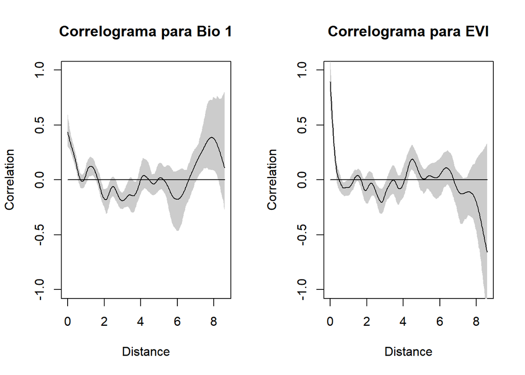

```r
# ¿Cómo se ven?
par(mfrow = c(1, 2))
plot(spline.cor.bio.chk)
title('Correlograma para Bio 1')
plot(spline.cor.evi.chk)
title('Correlograma para EVI')
```

Aplicamos el test de Moran a cada conjunto de datos.

```r
m.test(chk1.bio.env[,c("longitude", "latitude")], chk1.bio.env$bio_1)
```

```
##
##  Monte-Carlo simulation of Moran I
##
## data:  envar
## weights: wts
## number of simulations + 1: 1000
##
## statistic = 0.87673, observed rank = 1000, p-value = 0.001
## alternative hypothesis: greater
```

```r
m.test(chk1.evi.env[,c("longitude", "latitude")], chk1.evi.env$EVI_mean)
```

```
##
##  Monte-Carlo simulation of Moran I
##
## data:  envar
## weights: wts
## number of simulations + 1: 1000
##
## statistic = 0.75818, observed rank = 1000, p-value = 0.001
## alternative hypothesis: greater
```

¿Hay evidencia de que nuestros registros se agrupen espacialmente?

## 3.4 Filtrado espacial: 5, 20, y 50 km.

Cargamos los archivos con las ocurrencias de la especie para cada filtro de distancia. Estos registros fueron filtrados previamente con el paquete [`spThin`](https://doi.org/10.1111/ecog.01132).

```r
occ.5km <- read_csv('occ_thin/thinned_data_thin_5km.csv')
occ.20km <- read_csv('occ_thin/thinned_data_thin_20km.csv')
occ.50km <- read_csv('occ_thin/thinned_data_thin_50km.csv')
```

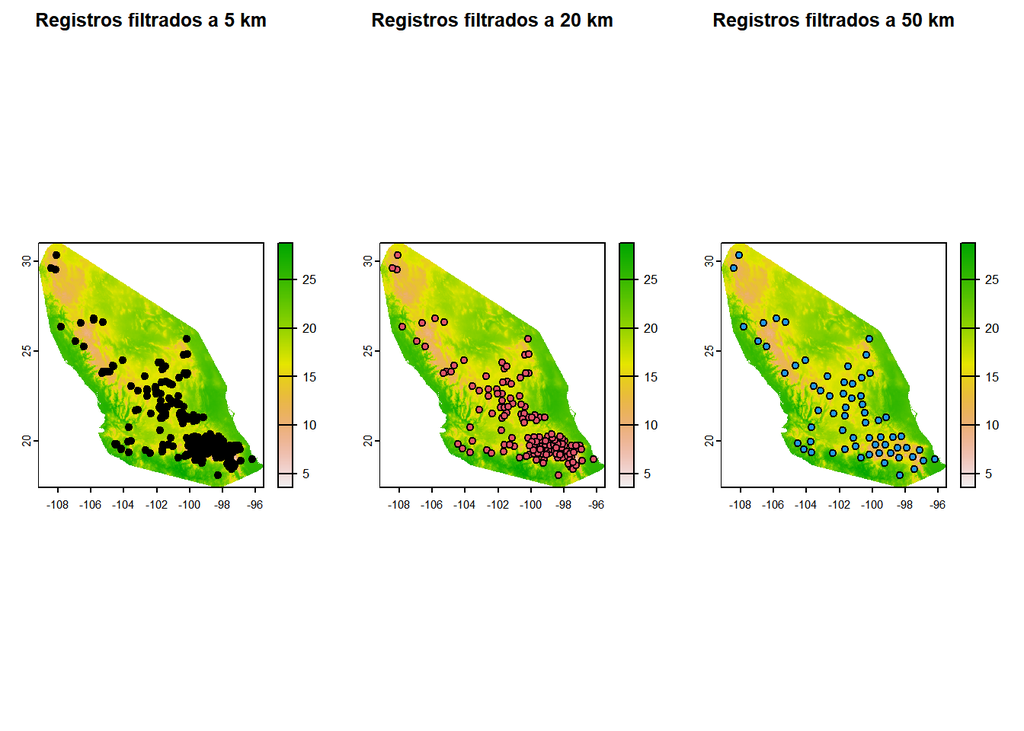

```r
# ¿Cómo se ve la dispersión de registros de presencia para cada distancia de filtrado?
par(mfrow = c(1, 3))
plot(bio1)
points(occ.5km$longitude, occ.5km$latitude, pch=21, bg=1)
title(main = "Registros filtrados a 5 km")

plot(bio1)
points(occ.20km$longitude, occ.20km$latitude, pch=21, bg=2)
title(main = "Registros filtrados a 20 km")

plot(bio1)
points(occ.50km$longitude, occ.50km$latitude, pch=21, bg=4)
title(main = "Registros filtrados a 50 km")
```

Extraemos los valores de cada variable.

```r
env.5k.bio1 <- terra::extract(bio1, occ.5km[, c("longitude", "latitude")], df = TRUE) %>% tibble() %>% .[,-1] %>% tibble(occ.5km[, c("longitude", "latitude")], .)

env.20k.bio1 <- terra::extract(bio1, occ.20km[, c("longitude", "latitude")], df = TRUE) %>% tibble() %>% .[,-1] %>% tibble(occ.20km[, c("longitude", "latitude")], .)

env.50k.bio1 <- terra::extract(bio1, occ.50km[, c("longitude", "latitude")], df = TRUE) %>% tibble() %>% .[,-1] %>% tibble(occ.50km[, c("longitude", "latitude")], .)

env.5k.evi <- terra::extract(evi.mean, occ.5km[, c("longitude", "latitude")], df = TRUE) %>% tibble() %>% .[,-1] %>% tibble(occ.5km[, c("longitude", "latitude")], .)

env.20k.evi <- terra::extract(evi.mean, occ.20km[, c("longitude", "latitude")], df = TRUE) %>% tibble() %>% .[,-1] %>% tibble(occ.20km[, c("longitude", "latitude")], .)

env.50k.evi <- terra::extract(evi.mean, occ.50km[, c("longitude", "latitude")], df = TRUE) %>% tibble() %>% .[,-1] %>% tibble(occ.50km[, c("longitude", "latitude")], .)
```

Calculamos las la matriz de distancias y la máxima distancia de los registros filtrados.

```r
dists.5km.bio <- calc.dists(env.5k.bio1)
dists.20km.bio <- calc.dists(env.20k.bio1)
dists.50km.bio <- calc.dists(env.50k.bio1)

dists.5km.evi <- calc.dists(env.5k.evi)
dists.20km.evi <- calc.dists(env.20k.evi)
dists.50km.evi <- calc.dists(env.50k.evi)
```

Calculamos los correlogramas suavizados con IC 95%.

```r
set.seed(123)
spline.corr.5k.bio <- spline.correlog(x = env.5k.bio1$longitude, y = env.5k.bio1$latitude, z = env.5k.bio1$bio_1, xmax = dists.5km.bio$maxdist, resamp = 100, type = "boot")
```

```
## 10  of  100
20  of  100
30  of  100
40  of  100
50  of  100
60  of  100
70  of  100
80  of  100
90  of  100
100  of  100
```

```r
set.seed(123)
spline.corr.20k.bio <- spline.correlog(x = env.20k.bio1$longitude, y = env.20k.bio1$latitude, z = env.20k.bio1$bio_1,xmax = dists.20km.bio$maxdist, resamp = 100, type = "boot")
```

```
## 10  of  100
20  of  100
30  of  100
40  of  100
50  of  100
60  of  100
70  of  100
80  of  100
90  of  100
100  of  100
```

```r
set.seed(123)
spline.corr.50k.bio <- spline.correlog(x = env.50k.bio1$longitude, y = env.50k.bio1$latitude, z = env.50k.bio1$bio_1, xmax = dists.50km.bio$maxdist, resamp = 100, type = "boot")
```

```
## 10  of  100
20  of  100
30  of  100
40  of  100
50  of  100
60  of  100
70  of  100
80  of  100
90  of  100
100  of  100
```

```r
set.seed(123)
spline.corr.5k.evi <- spline.correlog(x = env.5k.evi$longitude, y = env.5k.evi$latitude, z = env.5k.evi$EVI_mean, xmax = dists.5km.evi$maxdist, resamp = 100, type = "boot")
```

```
## 10  of  100
20  of  100
30  of  100
40  of  100
50  of  100
60  of  100
70  of  100
80  of  100
90  of  100
100  of  100
```

```r
set.seed(123)
spline.corr.20k.evi <- spline.correlog(x = env.20k.evi$longitude, y = env.20k.evi$latitude, z = env.20k.evi$EVI_mean,xmax = dists.20km.evi$maxdist, resamp = 100, type = "boot")
```

```
## 10  of  100
20  of  100
30  of  100
40  of  100
50  of  100
60  of  100
70  of  100
80  of  100
90  of  100
100  of  100
```

```r
set.seed(123)
spline.corr.50k.evi <- spline.correlog(x = env.50k.evi$longitude, y = env.50k.evi$latitude, z = env.50k.evi$EVI_mean, xmax = dists.50km.evi$maxdist, resamp = 100, type = "boot")
```

```
## 10  of  100
20  of  100
30  of  100
40  of  100
50  of  100
60  of  100
70  of  100
80  of  100
90  of  100
100  of  100
```

¿Cómo se ven?

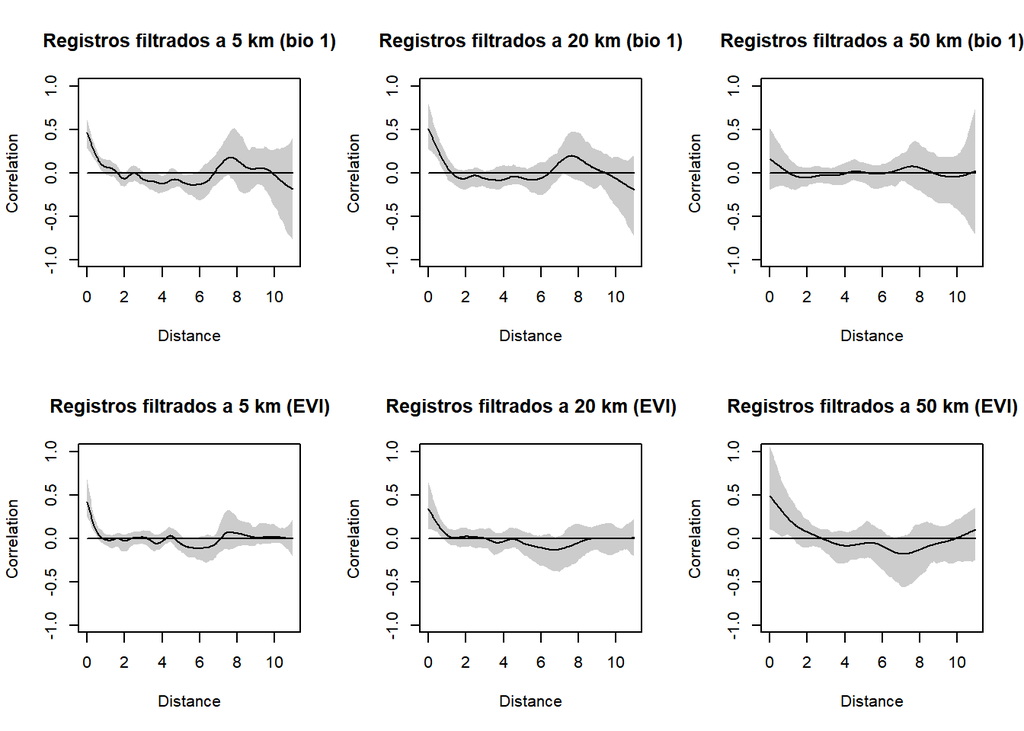

```r
par(mfrow = c(2, 3))
plot(spline.corr.5k.bio)
title(main = "Registros filtrados a 5 km (bio 1)")
plot(spline.corr.20k.bio)
title(main = "Registros filtrados a 20 km (bio 1)")
plot(spline.corr.50k.bio)
title(main = "Registros filtrados a 50 km (bio 1)")

plot(spline.corr.5k.evi)
title(main = "Registros filtrados a 5 km (EVI)")
plot(spline.corr.20k.evi)
title(main = "Registros filtrados a 20 km (EVI)")
plot(spline.corr.50k.evi)
title(main = "Registros filtrados a 50 km (EVI)")
```

```r
par(mfrow = c(1, 1))
```

Aplicamos el test de Moran a cada conjunto de datos.

```r
m.test(env.5k.bio1[,c("longitude", "latitude")], env.5k.bio1$bio_1, d2 = 6)
```

```
##
##  Monte-Carlo simulation of Moran I
##
## data:  envar
## weights: wts
## number of simulations + 1: 1000
##
## statistic = 0.1195, observed rank = 997, p-value = 0.003
## alternative hypothesis: greater
```

```r
m.test(env.20k.bio1[,c("longitude", "latitude")], env.20k.bio1$bio_1, 20)
```

```
##
##  Monte-Carlo simulation of Moran I
##
## data:  envar
## weights: wts
## number of simulations + 1: 1000
##
## statistic = 0.015419, observed rank = 935, p-value = 0.065
## alternative hypothesis: greater
```

```r
m.test(env.50k.bio1[,c("longitude", "latitude")], env.50k.bio1$bio_1, d2 = 51)
```

```
##
##  Monte-Carlo simulation of Moran I
##
## data:  envar
## weights: wts
## number of simulations + 1: 1000
##
## statistic = 0.0051533, observed rank = 602, p-value = 0.398
## alternative hypothesis: greater
```

```r
m.test(env.5k.evi[,c("longitude", "latitude")], env.5k.evi$EVI_mean, d2 = 6)
```

```
##
##  Monte-Carlo simulation of Moran I
##
## data:  envar
## weights: wts
## number of simulations + 1: 1000
##
## statistic = 0.17799, observed rank = 1000, p-value = 0.001
## alternative hypothesis: greater
```

```r
m.test(env.20k.evi[,c("longitude", "latitude")], env.20k.evi$EVI_mean, 20)
```

```
##
##  Monte-Carlo simulation of Moran I
##
## data:  envar
## weights: wts
## number of simulations + 1: 1000
##
## statistic = 0.0091423, observed rank = 827, p-value = 0.173
## alternative hypothesis: greater
```

```r
m.test(env.50k.evi[,c("longitude", "latitude")], env.50k.evi$EVI_mean, d2 = 51)
```

```
##
##  Monte-Carlo simulation of Moran I
##
## data:  envar
## weights: wts
## number of simulations + 1: 1000
##
## statistic = 0.007642, observed rank = 612, p-value = 0.388
## alternative hypothesis: greater
```

¿Cambia la autocorrelación respecto a la distancia, y la variable ambiental utilizada, cuál tiene mayor autocorrelación?

## 3.5 Filtrado ambiental con el paquete [`flexsdm`](https://sjevelazco.github.io/flexsdm/).

En este apartado utilizaremos la función `occfilt_env()` del paquete `flexsdm`. Esta función realiza un filtrado de los registros en función de sus condiciones ambientales. Nota: considérese una compensación entre el número de “bins” y el número de registros filtrados, porque a medida que el número de “bins” disminuye, el tamaño de las celdas de las cuadrículas aumenta y el número de registros filtrados disminuye (Castellanos et al., 2019).

Para este ejercicio usaremos distintos valores de “bins”.

```r
#Agregar un identificador necesario para aplicar este método.
spp.ID <- mutate(spp, ID = 1:nrow(spp))

set.seed(123)
bio.f.E.20b <- occfilt_env(data = spp.ID, x = 'longitude', y = 'latitude', id = 'ID', env_layer = bio1, nbins = 20)
```

```
## Extracting values from raster ...
```

```
## Number of unfiltered records: 728
```

```
## Number of filtered records: 19
```

```r
set.seed(123)
bio.f.E.30b <- occfilt_env(data = spp.ID, x = 'longitude', y = 'latitude', id = 'ID', env_layer = bio1, nbins = 30)
```

```
## Extracting values from raster ...
```

```
## Number of unfiltered records: 728
```

```
## Number of filtered records: 27
```

```r
set.seed(123)
bio.f.E.50b <- occfilt_env(data = spp.ID, x = 'longitude', y = 'latitude', id = 'ID', env_layer = bio1, nbins = 50)
```

```
## Extracting values from raster ...
```

```
## Number of unfiltered records: 728
```

```
## Number of filtered records: 39
```

```r
set.seed(123)
evi.f.E.20b <- occfilt_env(data = spp.ID, x = 'longitude', y = 'latitude', id = 'ID', env_layer = evi.mean, nbins = 20)
```

```
## Extracting values from raster ...
```

```
## Number of unfiltered records: 728
```

```
## Number of filtered records: 19
```

```r
set.seed(123)
evi.f.E.30b <- occfilt_env(data = spp.ID, x = 'longitude', y = 'latitude', id = 'ID', env_layer = evi.mean, nbins = 30)
```

```
## Extracting values from raster ...
```

```
## Number of unfiltered records: 728
```

```
## Number of filtered records: 27
```

```r
set.seed(123)
evi.f.E.50b <- occfilt_env(data = spp.ID, x = 'longitude', y = 'latitude', id = 'ID', env_layer = evi.mean, nbins = 50)
```

```
## Extracting values from raster ...
```

```
## Number of unfiltered records: 728
```

```
## Number of filtered records: 43
```

¿Cómo se ve la distribución de registros mediante filtrado ambiental?

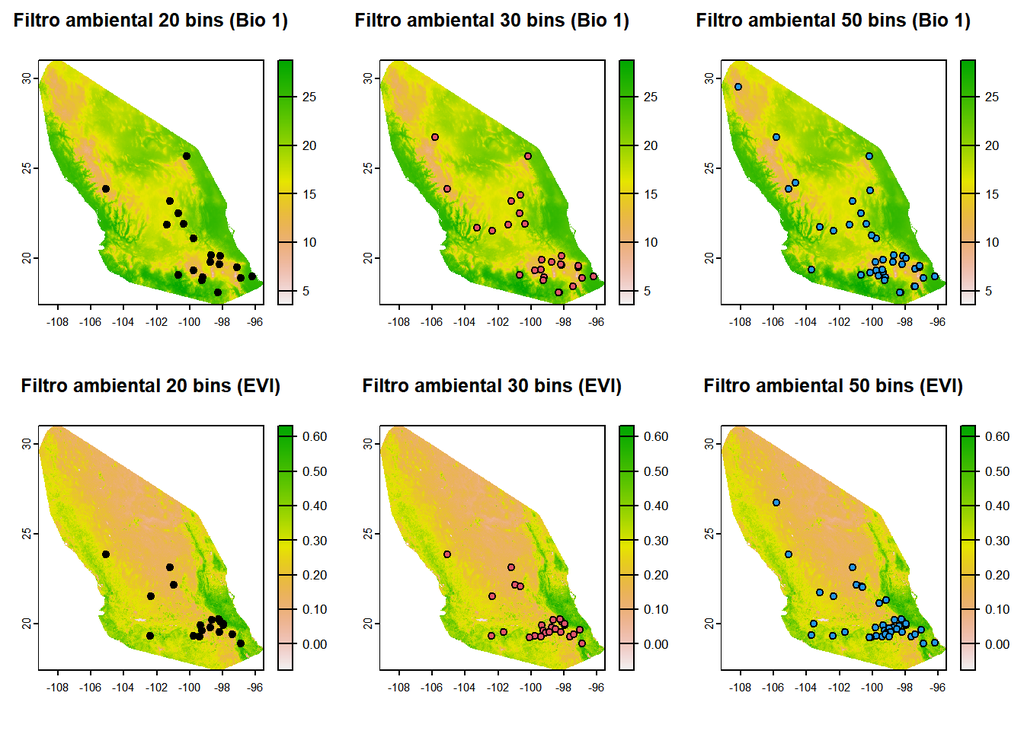

```r
par(mfrow = c(2, 3))
plot(bio1)
points(bio.f.E.20b[, 2:3], pch=21, bg=1)
title(main = "Filtro ambiental 20 bins (Bio 1)")
plot(bio1)
points(bio.f.E.30b[, 2:3], pch=21, bg=2)
title(main = "Filtro ambiental 30 bins (Bio 1)")
plot(bio1)
points(bio.f.E.50b[, 2:3], pch=21, bg=4)
title(main = "Filtro ambiental 50 bins (Bio 1)")

plot(evi.mean)
points(evi.f.E.20b[, 2:3], pch=21, bg=1)
title(main = "Filtro ambiental 20 bins (EVI)")
plot(evi.mean)
points(evi.f.E.30b[, 2:3], pch=21, bg=2)
title(main = "Filtro ambiental 30 bins (EVI)")
plot(evi.mean)
points(evi.f.E.50b[, 2:3], pch=21, bg=4)
title(main = "Filtro ambiental 50 bins (EVI)")
```

Extraemos los valores ambientales de cada variable.

```r
bio.f.E.20b.env <- terra::extract(bio1, bio.f.E.20b[, c("longitude", "latitude")], df = TRUE) %>% tibble() %>% .[,-1] %>% tibble(bio.f.E.20b[, c("longitude", "latitude")], .)

bio.f.E.30b.env <- terra::extract(bio1, bio.f.E.30b[, c("longitude", "latitude")], df = TRUE) %>% tibble() %>% .[,-1] %>% tibble(bio.f.E.30b[, c("longitude", "latitude")], .)

bio.f.E.50b.env <- terra::extract(bio1, bio.f.E.50b[, c("longitude", "latitude")], df = TRUE) %>% tibble() %>% .[,-1] %>% tibble(bio.f.E.50b[, c("longitude", "latitude")], .)

evi.f.E.20b.env <- terra::extract(evi.mean, evi.f.E.20b[, c("longitude", "latitude")], df = TRUE) %>% tibble() %>% .[,-1] %>% tibble(evi.f.E.20b[, c("longitude", "latitude")], .)

evi.f.E.30b.env <- terra::extract(evi.mean, evi.f.E.30b[, c("longitude", "latitude")], df = TRUE) %>% tibble() %>% .[,-1] %>% tibble(evi.f.E.30b[, c("longitude", "latitude")], .)

evi.f.E.50b.env <- terra::extract(evi.mean, evi.f.E.50b[, c("longitude", "latitude")], df = TRUE) %>% tibble() %>% .[,-1] %>% tibble(evi.f.E.50b[, c("longitude", "latitude")], .)
```

Calculamos las la matriz de distancias y la máxima distancia de los registros filtrados.

```r
dists.20b.bio <- calc.dists(bio.f.E.20b.env)
dists.30b.bio <- calc.dists(bio.f.E.30b.env)
dists.50b.bio <- calc.dists(bio.f.E.50b.env)

dists.20b.evi <- calc.dists(evi.f.E.20b.env)
dists.30b.evi <- calc.dists(evi.f.E.30b.env)
dists.50b.evi <- calc.dists(evi.f.E.50b.env)
```

Calculamos los correlogramas suavizados con IC 95%.

```r
set.seed(123)
spline.corr.20b.bio <- spline.correlog(x = bio.f.E.20b.env$longitude, y = bio.f.E.20b.env$latitude, z = bio.f.E.20b.env$bio_1, xmax = dists.20b.bio$maxdist, resamp = 100, type = "boot")
```

```
## 10  of  100
20  of  100
30  of  100
40  of  100
50  of  100
60  of  100
70  of  100
80  of  100
90  of  100
100  of  100
```

```r
set.seed(123)
spline.corr.30b.bio <- spline.correlog(x = bio.f.E.30b.env$longitude, y = bio.f.E.30b.env$latitude, z = bio.f.E.30b.env$bio_1, xmax = dists.30b.bio$maxdist, resamp = 100, type = "boot")
```

```
## 10  of  100
20  of  100
30  of  100
40  of  100
50  of  100
60  of  100
70  of  100
80  of  100
90  of  100
100  of  100
```

```r
set.seed(123)
spline.corr.50b.bio <- spline.correlog(x = bio.f.E.50b.env$longitude, y = bio.f.E.50b.env$latitude, z = bio.f.E.50b.env$bio_1, xmax = dists.50b.bio$maxdist, resamp = 100, type = "boot")
```

```
## 10  of  100
20  of  100
30  of  100
40  of  100
50  of  100
60  of  100
70  of  100
80  of  100
90  of  100
100  of  100
```

```r
set.seed(123)
spline.corr.20b.evi <- spline.correlog(x = evi.f.E.20b.env$longitude, y = evi.f.E.20b.env$latitude, z = evi.f.E.20b.env$EVI_mean, xmax = dists.20b.evi$maxdist, resamp = 100, type = "boot")
```

```
## 10  of  100
20  of  100
30  of  100
40  of  100
50  of  100
60  of  100
70  of  100
80  of  100
90  of  100
100  of  100
```

```r
set.seed(123)
spline.corr.30b.evi <- spline.correlog(x = evi.f.E.30b.env$longitude, y = evi.f.E.30b.env$latitude, z = evi.f.E.30b.env$EVI_mean, xmax = dists.30b.evi$maxdist, resamp = 100, type = "boot")
```

```
## 10  of  100
20  of  100
30  of  100
40  of  100
50  of  100
60  of  100
70  of  100
80  of  100
90  of  100
100  of  100
```

```r
set.seed(123)
spline.corr.50b.evi <- spline.correlog(x = evi.f.E.50b.env$longitude, y = evi.f.E.50b.env$latitude, z = evi.f.E.50b.env$EVI_mean, xmax = dists.50b.evi$maxdist, resamp = 100, type = "boot")
```

```
## 10  of  100
20  of  100
30  of  100
40  of  100
50  of  100
60  of  100
70  of  100
80  of  100
90  of  100
100  of  100
```

¿Cómo se ven los correlogramas?

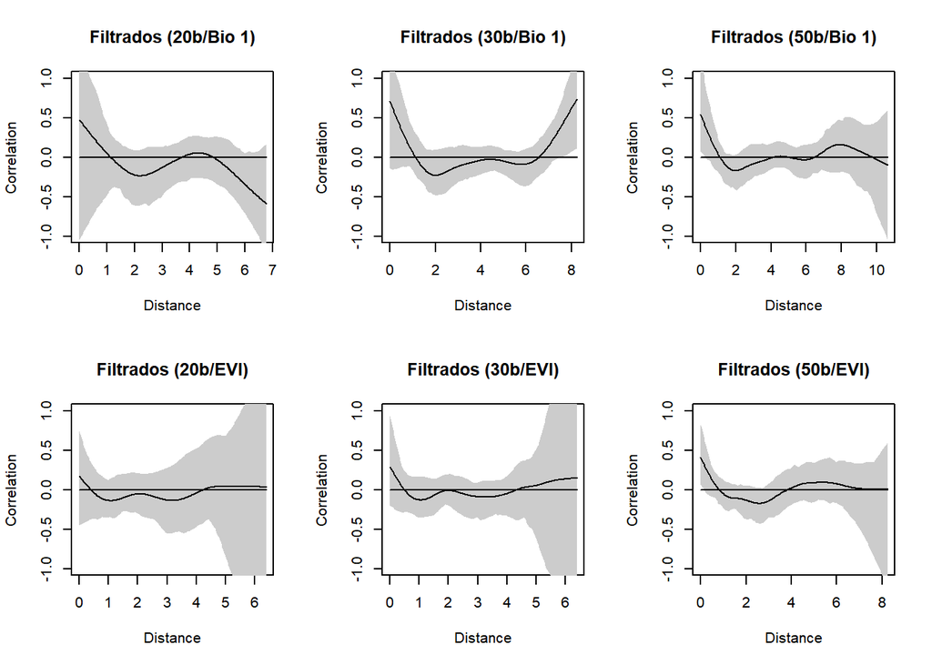

```r
par(mfrow = c(2, 3))
plot(spline.corr.20b.bio)
title(main = "Filtrados (20b/Bio 1)")
plot(spline.corr.30b.bio)
title(main = "Filtrados (30b/Bio 1)")
plot(spline.corr.50b.bio)
title(main = "Filtrados (50b/Bio 1)")

plot(spline.corr.20b.evi)
title(main = "Filtrados (20b/EVI)")
plot(spline.corr.30b.evi)
title(main = "Filtrados (30b/EVI)")
plot(spline.corr.50b.evi)
title(main = "Filtrados (50b/EVI)")
```

Aplicamos el test de Moran a cada conjunto de datos.

```r
m.test(bio.f.E.20b.env[,c("longitude", "latitude")], bio.f.E.20b.env$bio_1, d2 = 25)
```

```
##
##  Monte-Carlo simulation of Moran I
##
## data:  envar
## weights: wts
## number of simulations + 1: 1000
##
## statistic = 0.069997, observed rank = 798, p-value = 0.202
## alternative hypothesis: greater
```

```r
m.test(bio.f.E.30b.env[,c("longitude", "latitude")], bio.f.E.30b.env$bio_1, d2 = 4)
```

```
##
##  Monte-Carlo simulation of Moran I
##
## data:  envar
## weights: wts
## number of simulations + 1: 1000
##
## statistic = 0.15954, observed rank = 972.5, p-value = 0.0275
## alternative hypothesis: greater
```

```r
m.test(bio.f.E.50b.env[,c("longitude", "latitude")], bio.f.E.50b.env$bio_1, d2 = 4)
```

```
##
##  Monte-Carlo simulation of Moran I
##
## data:  envar
## weights: wts
## number of simulations + 1: 1000
##
## statistic = 0.17421, observed rank = 987, p-value = 0.013
## alternative hypothesis: greater
```

```r
m.test(evi.f.E.20b.env[,c("longitude", "latitude")], evi.f.E.20b.env$EVI_mean, d2 = 3)
```

```
##
##  Monte-Carlo simulation of Moran I
##
## data:  envar
## weights: wts
## number of simulations + 1: 1000
##
## statistic = 0.16117, observed rank = 949.5, p-value = 0.0505
## alternative hypothesis: greater
```

```r
m.test(evi.f.E.30b.env[,c("longitude", "latitude")], evi.f.E.30b.env$EVI_mean, d2 = 3)
```

```
##
##  Monte-Carlo simulation of Moran I
##
## data:  envar
## weights: wts
## number of simulations + 1: 1000
##
## statistic = 0.13424, observed rank = 968, p-value = 0.032
## alternative hypothesis: greater
```

```r
m.test(evi.f.E.50b.env[,c("longitude", "latitude")], evi.f.E.50b.env$EVI_mean, d2 = 3)
```

```
##
##  Monte-Carlo simulation of Moran I
##
## data:  envar
## weights: wts
## number of simulations + 1: 1000
##
## statistic = 0.13505, observed rank = 956, p-value = 0.044
## alternative hypothesis: greater
```

¿Hay evidencia de que nuestros registros se agrupen espacialmente, bajo que configuración?

## 3.6 Filtrado geográfico a partir del I de Moran.

Este enfoque realiza un filtrado geográfico de las ocurrencias de especies para definir la distancia mínima de vecino más cercano entre los puntos. Esta función implementa tres alternativas para determinar el umbral de distancia entre pares de puntos: 1-“morán” determina la distancia mínima vecina más cercana que minimiza la autocorrelación espacial en los datos de ocurrencia, siguiendo un semivariograma de Moran.

En este caso utilizamos solo una variable ambiental, pero podemos filtrar los datos para un conjunto de variables ambientales (Stack raster), para ello, se implementa un Análisis de Componentes Principales con las variables ambientales y luego se utiliza el primer Componente Principal para calcular los semivariogramas.

En este caso utilizaremos `method = c('moran')`.

```r
set.seed(123)
G.f.Moran.bio <- occfilt_geo(data = spp, x = 'longitude', y = 'latitude', env_layer = bio1,  method = c('moran'), crs(bio1))
```

```
## Extracting values from raster ...
```

```
## Number of unfiltered records: 728
```

```
## Threshold for Moran: 0.1
```

```
## Distance threshold(km): 231.679
```

```
## Number of filtered records: 11
```

```r
set.seed(123)
G.f.Moran.evi <- occfilt_geo(data = spp, x = 'longitude', y = 'latitude', env_layer = evi.mean,  method = c('moran'), crs(evi.mean))
```

```
## Extracting values from raster ...
```

```
## Number of unfiltered records: 728
```

```
## Threshold for Moran: 0.1
```

```
## Distance threshold(km): 115.839
```

```
## Number of filtered records: 27
```

¿Cómo se ve la distribución espacial de los registros por este método de filtrado?

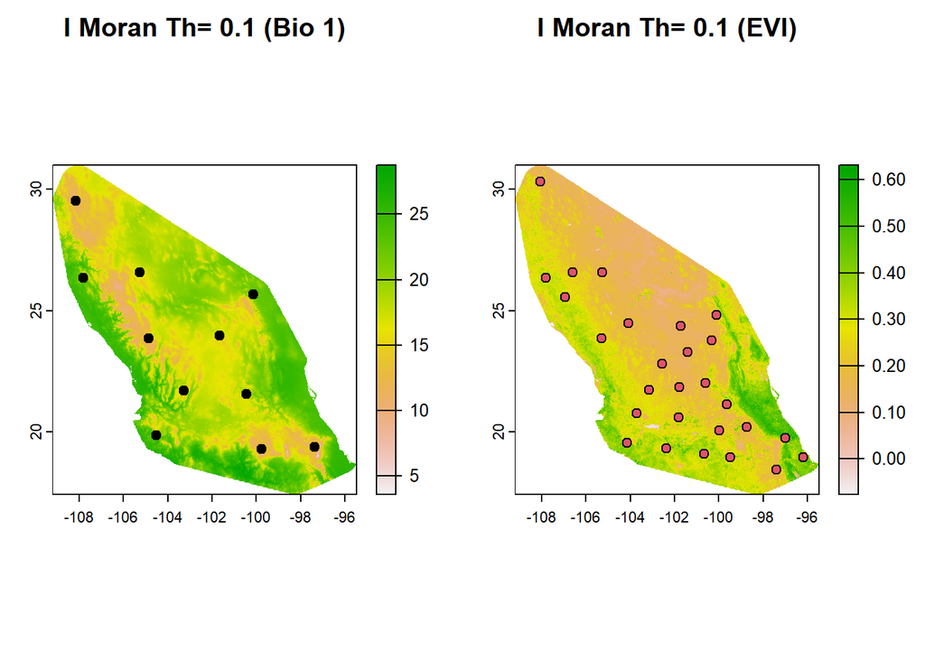

```r
par(mfrow = c(1, 2))
plot(bio1)
points(G.f.Moran.bio[, c('longitude', 'latitude')], pch=21, bg=1)
title(main = "I Moran Th= 0.1 (Bio 1)")
plot(evi.mean)
points(G.f.Moran.evi[, c('longitude', 'latitude')], pch=21, bg=2)
title(main = "I Moran Th= 0.1 (EVI)")
```

Extraemos los valores ambientales de cada variable.

```r
G.Moran.bio <- terra::extract(bio1, G.f.Moran.bio[, c("longitude", "latitude")], df = TRUE) %>% tibble() %>% .[,-1] %>% tibble(G.f.Moran.bio[, c("longitude", "latitude")], .)
G.Moran.evi <- terra::extract(evi.mean, G.f.Moran.evi[, c("longitude", "latitude")], df = TRUE) %>% tibble() %>% .[,-1] %>% tibble(G.f.Moran.evi[, c("longitude", "latitude")], .)
```

Calculamos las la matriz de distancias y la máxima distancia de los registros filtrados.

```r
dists.Moran.bio <- calc.dists(G.Moran.bio)
dists.Moran.evi <- calc.dists(G.Moran.evi)
```

Calculamos los correlogramas suavizados con IC 95%.

```r
set.seed(123)
spline.moran.bio <- spline.correlog(x = G.Moran.bio$longitude, y = G.Moran.bio$latitude, z = G.Moran.bio$bio_1, xmax = dists.Moran.bio$maxdist, resamp = 100, type = "boot")
```

```
## 10  of  100
20  of  100
30  of  100
40  of  100
50  of  100
60  of  100
70  of  100
80  of  100
90  of  100
100  of  100
```

```r
set.seed(123)
spline.moran.evi <- spline.correlog(x = G.Moran.evi$longitude, y = G.Moran.evi$latitude, z = G.Moran.evi$EVI_mean, xmax = dists.Moran.evi$maxdist, resamp = 100, type = "boot")
```

```
## 10  of  100
20  of  100
30  of  100
40  of  100
50  of  100
60  of  100
70  of  100
80  of  100
90  of  100
100  of  100
```

¿Cómo se ven? ¿Se percibe la eliminación de la autocorrelación espacial?

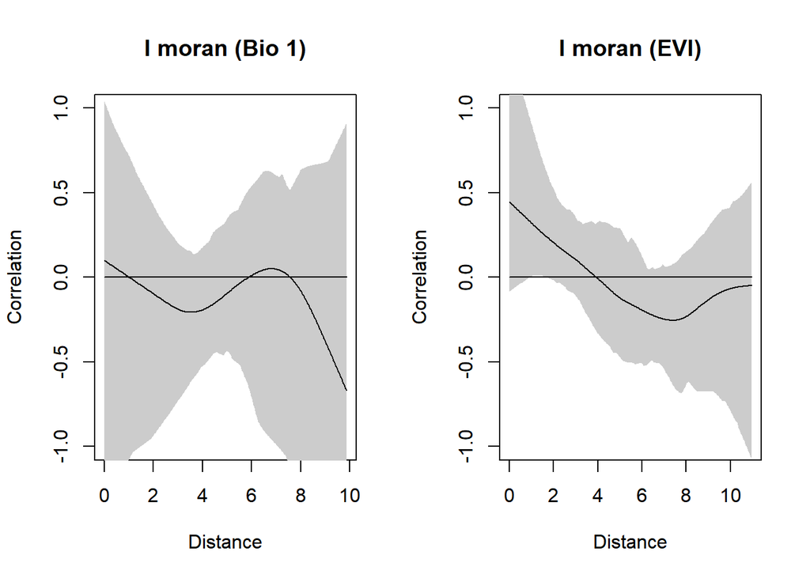

```r
par(mfrow = c(1, 2))
plot(spline.moran.bio)
title(main = "I moran (Bio 1)")
plot(spline.moran.evi)
title(main = "I moran (EVI)")
```

Aplicamos el test de Moran a cada conjunto de datos para comprobar.

```r
m.test(G.Moran.bio[,c("longitude", "latitude")], G.Moran.bio$bio_1, d2 = 241)
```

```
##
##  Monte-Carlo simulation of Moran I
##
## data:  envar
## weights: wts
## number of simulations + 1: 1000
##
## statistic = 0.002828, observed rank = 612.5, p-value = 0.3875
## alternative hypothesis: greater
```

```r
m.test(G.Moran.evi[,c("longitude", "latitude")], G.Moran.evi$EVI_mean, d2 = 120)
```

```
##
##  Monte-Carlo simulation of Moran I
##
## data:  envar
## weights: wts
## number of simulations + 1: 1000
##
## statistic = 0.047145, observed rank = 736, p-value = 0.264
## alternative hypothesis: greater
```

¿Qué podemos concluir, con cual método te quedas?

¿Eliminar completamente la dependencia espacial de los registros ayudará a generar mejores ENMs?